# Econ 334 Group Project (HEMA)

### Scatterplot of Actual vs Predicted Values

In order to visualise the accuracy of the model, a scatterplot of actual vs predicted values is generated in ggplot.

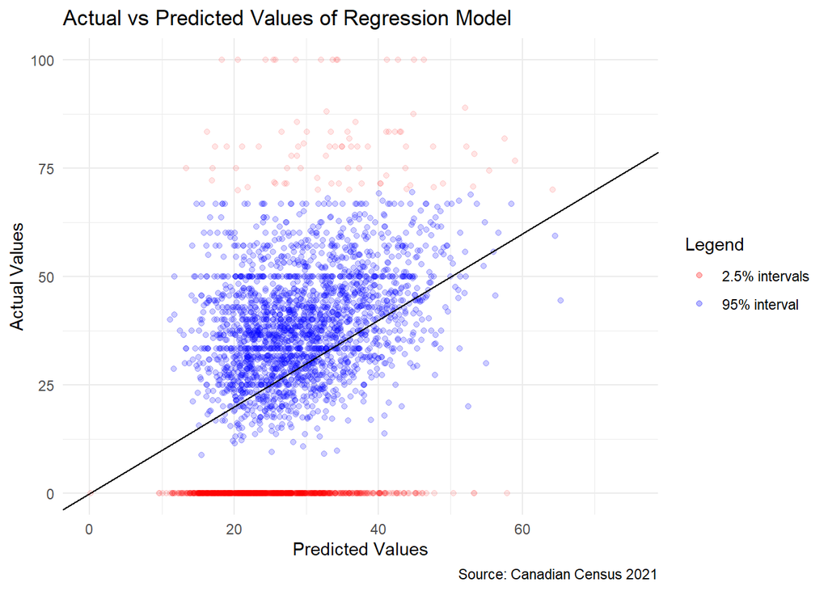

```r
cd2021.var <- na.omit(cd2021.var)
cd2021.var$y.pred = predict(out)

colors <- c('95% interval'='blue',
            '2.5% intervals'='red')

ggplot(cd2021.var,aes(x=y.pred, y=y.perc))+
  geom_point(data=subset(cd2021.var, y.perc>0 & y.perc<69.8), alpha=0.2, aes(color='95% interval'))+
  geom_abline(intercept=0, slope=1)+
  geom_point(data=subset(cd2021.var,y.perc>=69.8 | y.perc==0), aes(color='2.5% intervals'), alpha=0.1)+
  theme_minimal()+
  labs(x='Predicted Values', y='Actual Values', color='Legend', title='Actual vs Predicted Values of Regression Model', caption='Source: Canadian Census 2021')+
  scale_color_manual(values=colors)+
  xlim(0,75)+
  ylim(0,100)+
  theme(legend.position='right')
```

The values of the 2.5% intervals and 95% intervals is found using the quantile() function

```r
quantile(cd2021.var$y.perc, probs=c(.025,0.5,.975), type=1,na.rm=TRUE)
```

```
 2.5%   50% 97.5%
  0.0  31.6  69.8
```

## Step 4: Apply the Underused Housing Tax

The size of this tax was estimated as 1% of the median property value (1%* 1,196,500) and applied to every underused property in a given dissemination area. Average tax payment were then adjusted to reflect the addition of this tax.

```r
cd2021.preds <- cd2021 %>%
  mutate(tax=(tax+(11965*unocc.d)/Population))
```

```r
cd2021.preds <- cd2021.preds %>%
  mutate(y.uht=predict(out, newdata=cd2021.preds))%>%
  drop_na()
```

## Step 5: Map the change in housing affordability after the tax is applied

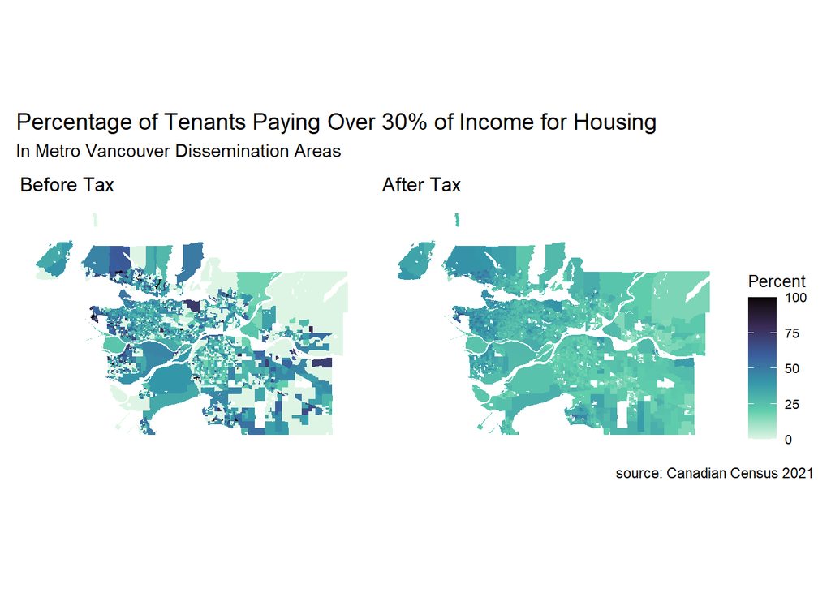

```r
mybreaks <- c(25, 50, 75, 100)

# in 2021
fig1 <- cd2021.preds %>% ggplot() +
  geom_sf(aes(fill = y.perc), color=NA) +
  scale_fill_viridis_c(option = "mako", direction = -1, limits = c(0, 100)) +
  theme_map() +
  labs(title = "Before Tax", fill = "Percent") + theme(legend.position="none", legend.title = element_text(size = 10), legend.text = element_text(size=8), title = element_text(size = 10))

# after unoccupied housing tax
fig2 <- cd2021.preds %>% ggplot() +
  geom_sf(aes(fill = y.uht), color=NA) +
  scale_fill_viridis_c(option = "mako", direction = -1, limits = c(0, 100)) +
    theme_map() +
  labs(title = "After Tax", fill = "Percent") + theme(legend.position="right", legend.title = element_text(size = 10), legend.text = element_text(size=8), title = element_text(size = 10))

fig1 + fig2 + plot_annotation('Percentage of Tenants Paying Over 30% of Income for Housing',subtitle = "In Metro Vancouver Dissemination Areas", caption = 'source: Canadian Census 2021', theme = theme(plot.title = element_text(size = 14)))
```